# Repertoire analysis

Clonal abundance, diversity and V-family gene usage

August 08, 2022

# Bcellmagic analysis pipeline

## Number of sequences

Number of reads for each of the samples and number of sequences left after representative analysis steps.

| ID | Source | Treatment | Extraction_time | Population | Sequences_R1 | Sequences_R2 | Filtered_quality_R1 | Filtered_quality_R2 | Mask_primers_R1 | Mask_primers_R2 | Paired | Build_consensus | Assemble_pairs | Unique | Representative_2 | Igblast |
| --- | --- | --- | --- | --- | --- | --- | --- | --- | --- | --- | --- | --- | --- | --- | --- | --- |
| QMKMK229AC | CLAD1B | Cladribin | baseline | DN | 1001901 | 1001901 | 998230 | 929323 | 950964 | 889152 | 874759 | 523735 | 90355 | 59292 | 8473 | 6791 |
| QMKMK230AF | CLAD1B | Cladribin | baseline | N | 601885 | 601885 | 599360 | 566181 | 571750 | 543140 | 533806 | 402066 | 97532 | 92699 | 6384 | 4471 |
| QMKMK231AN | CLAD1B | Cladribin | baseline | M | 1036290 | 1036290 | 1033363 | 964197 | 980082 | 919636 | 904197 | 780526 | 135769 | 124173 | 4958 | 4670 |
| QMKMK232AV | CLAD1B | Cladribin | baseline | P | 1352414 | 1352414 | 1346800 | 1262235 | 1290104 | 1212304 | 1196447 | 939219 | 149869 | 130718 | 7715 | 6761 |
| QMKMK233A5 | CLAD1C | Cladribin | 6months | DN | 1223690 | 1223690 | 1218476 | 1135468 | 1160160 | 1085218 | 1067347 | 791259 | 164345 | 121161 | 12723 | 11199 |
| QMKMK234AD | CLAD1C | Cladribin | 6months | N | 577697 | 577697 | 574852 | 539847 | 539088 | 508859 | 500228 | 385785 | 89640 | 88086 | 4824 | 3042 |
| QMKMK235AL | CLAD1C | Cladribin | 6months | M | 801072 | 801072 | 799337 | 750714 | 761523 | 718534 | 706606 | 608541 | 111207 | 95243 | 4519 | 4087 |
| QMKMK236AT | CLAD1C | Cladribin | 6months | P | 2043123 | 2043123 | 2033938 | 1877437 | 1930800 | 1784871 | 1761332 | 1235841 | 181411 | 160569 | 15490 | 13604 |
| QMKMK241AU | CLAD1D | Cladribin | 12months | DN | 1857453 | 1857453 | 1847028 | 1701105 | 1709731 | 1569714 | 1550126 | 857643 | 153793 | 117453 | 14307 | 11728 |
| QMKMK242A4 | CLAD1D | Cladribin | 12months | M | 1850771 | 1850771 | 1846857 | 1708178 | 1770918 | 1632432 | 1611884 | 1280996 | 217152 | 195283 | 10504 | 7908 |
| QMKMK243AC | CLAD1D | Cladribin | 12months | N | 1244736 | 1244736 | 1242282 | 1135476 | 1178264 | 1075176 | 1059637 | 679954 | 139280 | 136735 | 15418 | 4904 |
| QMKMK244AK | CLAD1D | Cladribin | 12months | P | 1811754 | 1811754 | 1807946 | 1664568 | 1739221 | 1597527 | 1577659 | 1079476 | 254312 | 209764 | 21119 | 17531 |
| QMKMK533AN | CLAD2B | Cladribin | baseline | N | 299299 | 299299 | 298776 | 284644 | 278650 | 263896 | 259773 | 136538 | 42888 | 21024 | 3065 | 2478 |
| QMKMK534AV | CLAD2B | Cladribin | baseline | M | 911354 | 911354 | 909208 | 856360 | 853308 | 802774 | 789542 | 619034 | 99507 | 87314 | 6089 | 5676 |
| QMKMK535A5 | CLAD2B | Cladribin | baseline | DN | 1548122 | 1548122 | 1546518 | 1485086 | 1455661 | 1392202 | 1373849 | 746018 | 162418 | 91819 | 14290 | 12021 |
| QMKMK536AD | CLAD2B | Cladribin | baseline | P | 828075 | 828075 | 826764 | 781959 | 769833 | 729669 | 715212 | 583392 | 116702 | 101158 | 7315 | 7063 |
| QMKMK537AL | CLAD2C | Cladribin | 6months | N | 1695948 | 1695948 | 1695010 | 1636672 | 1564060 | 1506398 | 1482971 | 541493 | 162342 | 145709 | 25033 | 10018 |
| QMKMK538AT | CLAD2C | Cladribin | 6months | M | 2467900 | 2467900 | 2466808 | 2356982 | 2309769 | 2200497 | 2169463 | 767598 | 187811 | 126228 | 19933 | 17408 |
| QMKMK539A3 | CLAD2C | Cladribin | 6months | DN | 1670407 | 1670407 | 1669498 | 1608729 | 1548656 | 1486886 | 1464870 | 472354 | 119636 | 57321 | 9888 | 8395 |
| QMKMK540A6 | CLAD2C | Cladribin | 6months | P | 1418658 | 1418658 | 1417830 | 1366294 | 1320682 | 1272534 | 1251506 | 771396 | 206753 | 144571 | 18111 | 16220 |
| QMKMK541AE | CLAD2D | Cladribin | 12months | N | 1254799 | 1254799 | 1253722 | 1212466 | 1174117 | 1107772 | 1090535 | 522116 | 180332 | 174805 | 16652 | 7429 |
| QMKMK542AM | CLAD2D | Cladribin | 12months | M | 2480119 | 2480119 | 2478403 | 2372338 | 2315848 | 2199929 | 2166193 | 1126337 | 265733 | 232683 | 15946 | 13289 |
| QMKMK543AU | CLAD2D | Cladribin | 12months | DN | 1492340 | 1492340 | 1491521 | 1430650 | 1373414 | 1309222 | 1288903 | 743613 | 187691 | 140125 | 15719 | 12861 |
| QMKMK544A4 | CLAD2D | Cladribin | 12months | P | 1104002 | 1104002 | 1103382 | 1063497 | 1036043 | 994570 | 979051 | 493551 | 147757 | 93526 | 13522 | 11413 |
| QMKMK545AC | CLAD3B | Cladribin | baseline | N | 1571620 | 1571620 | 1570771 | 1523584 | 1497824 | 1451341 | 1431781 | 543131 | 171670 | 143580 | 26461 | 14093 |
| QMKMK546AK | CLAD3B | Cladribin | baseline | M | 1798031 | 1798031 | 1796794 | 1739586 | 1712984 | 1656005 | 1636655 | 1007055 | 254909 | 229384 | 13572 | 12353 |
| QMKMK547AS | CLAD3B | Cladribin | baseline | DN | 1325826 | 1325826 | 1324051 | 1277183 | 1262297 | 1218805 | 1199399 | 629789 | 146170 | 105951 | 13941 | 11564 |
| QMKMK548A2 | CLAD3B | Cladribin | baseline | P | 1375460 | 1375460 | 1374152 | 1327752 | 1308934 | 1264258 | 1245115 | 730531 | 161037 | 141148 | 13243 | 12400 |
| QMKMK549AA | CLAD3C | Cladribin | 6months | N | 1385899 | 1385899 | 1385012 | 1335147 | 1305595 | 1255991 | 1239376 | 490510 | 158561 | 140711 | 30700 | 13134 |
| QMKMK550AD | CLAD3C | Cladribin | 6months | M | 1240876 | 1240876 | 1240142 | 1207393 | 1183864 | 1149887 | 1136654 | 681733 | 204625 | 143603 | 17405 | 15518 |

[output cut: 66 more lines]

Plotting number of unique sequences

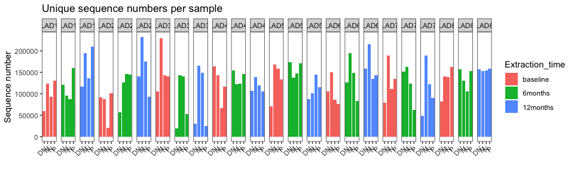

Plotting number of representative 2 sequences

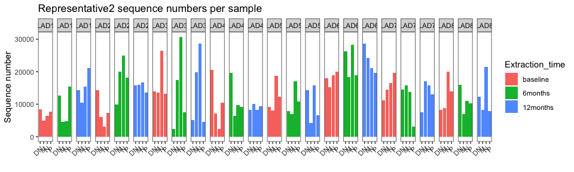

Plotting number of Igblast identified sequences

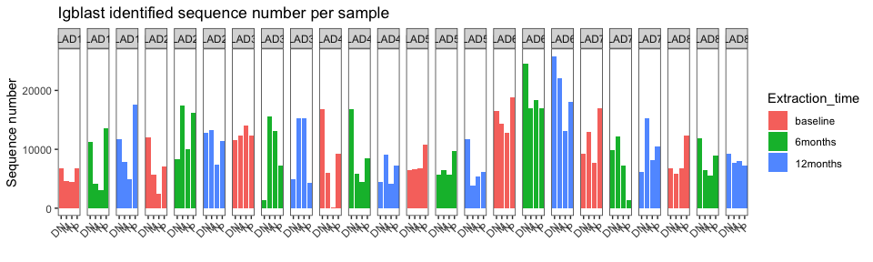

# Clonal abundance

For plotting the clonal abundance, the clones were ordered by size from bigger clones to smaller clones (x-axis, Rank). The Abundance of each clone was represented as the percentage of unique sequences in the clone, with respect to the total number of unique sequences in that subject (By Patient) or in the B-cell or T-cell sample (By Cell Population).

To correct for the different number of sequences in each of the samples, the Bootstrapping technique was employed, in which 200 random bootstrap samples were taken, with size the number of sequences in the sample with less sequences (N). The solid line shows the mean Abundance of the bootstrap samples, whereas the transparent area shows the full Abundance range of the bootstrap samples.

All clonal abundance plots and tables with abundance values can be found under `repertoire_analysis/Abundance`.

## Clonal abundance per subject

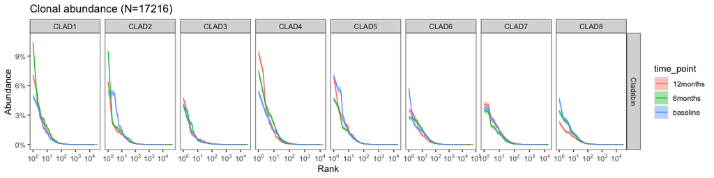

## Count clones per subject

```r
df_countclones_copy <- countClones(df_all,groups="sample",copy = "duplicate_count")
df_countclones_copy$treatment <- sapply(df_countclones_copy$sample, function(x) unlist(strsplit(as.character(x), "_"))[1])
df_countclones_copy$time_point <- sapply(df_countclones_copy$sample, function(x) unlist(strsplit(as.character(x), "_"))[2])
df_countclones_copy$patient <- sapply(df_countclones_copy$sample, function(x) unlist(strsplit(as.character(x), "_"))[3])
write.table(df_countclones_copy, file = paste0(abundance_dir, "/Clonal_numbers_data_subject.tsv"), sep = "\t", quote = F, row.names = F)
```

## Clonal abundance per cell population

If different types of B-cell or T-cell populations are provided, here the clonal abundance is plotted for each patient and B / T-cell population.

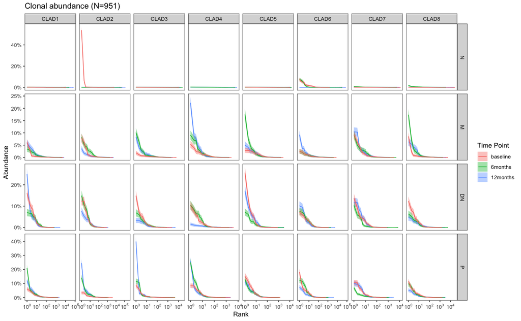

## Count clones per population

## Clonal diversification index

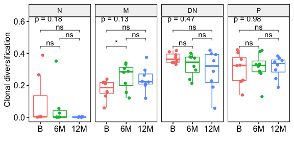

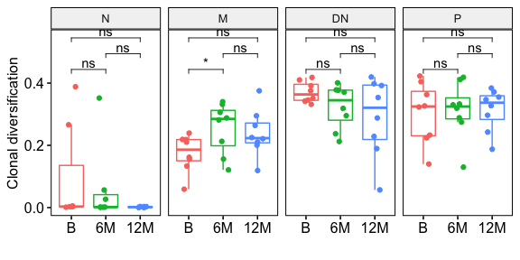

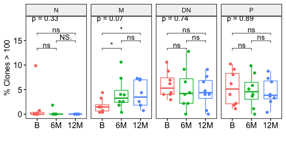

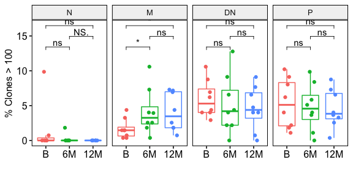

## Count clones per population

```r
df_countclones_copy <- countClones(df_all,groups="sample_pop",copy = "duplicate_count")
df_countclones_copy$treatment <- sapply(df_countclones_copy$sample_pop, function(x) unlist(strsplit(as.character(x), "_"))[1])
df_countclones_copy$time_point <- sapply(df_countclones_copy$sample_pop, function(x) unlist(strsplit(as.character(x), "_"))[2])
df_countclones_copy$patient <- sapply(df_countclones_copy$sample_pop, function(x) unlist(strsplit(as.character(x), "_"))[3])
df_countclones_copy$population <- sapply(df_countclones_copy$sample_pop, function(x)
unlist(strsplit(as.character(x), "_"))[4])
write.table(df_countclones_copy, file = paste0(abundance_dir, "/Clonal_numbers_data_subject_population.tsv"), sep = "\t", quote = F, row.names = F)
```

# Clonal diversity

The clonal diversity $D$ of the repertoire was calculated according to the general formula of Hill Diversity numbers:

$$\begin{aligned}
^{q}D = \left( \sum_{i=1}^Rp_i^q \right)^{1/(1-q)}
\end{aligned}$$

where:

- $p_i$ is the proportion of unique sequences belonging to clone $i$.
- $q$ are the values of the different diversity numbers.
- $R$ is the Richness, the number of different clones in the sample.

At $q=1$ the function is undefined and the limit to zero equals the exponential of the Shannon Entropy:

$$\begin{aligned}
^{1}D = exp \left( \sum_{i=1}^Rp_i ln(p_i) \right)
\end{aligned}$$

The intuition about the different Hill Diversity values is the following:

- At $q=0$ the diversity index equals the number of clones in the sample.
- At $q=1$ the diversity index is the geometric mean of the clones in the sample, weighted by their proportion in the sample.
- At $q>1$ more weight is given to the clones with higher proportions in the sample.

All clonal diversity plots and tables with diversity values can be found under `repertoire_analysis/Diversity`. To correct for the different number of sequences in each of the samples, the Bootstrapping technique was employed, in which 200 random bootstrap samples were taken, with size the number of sequences in the sample with less sequences (N). The solid line shows the mean Diversity of the bootstrap samples, whereas the transparent area shows the full Diversity range of the bootstrap samples.

## Clonal diversity per subject

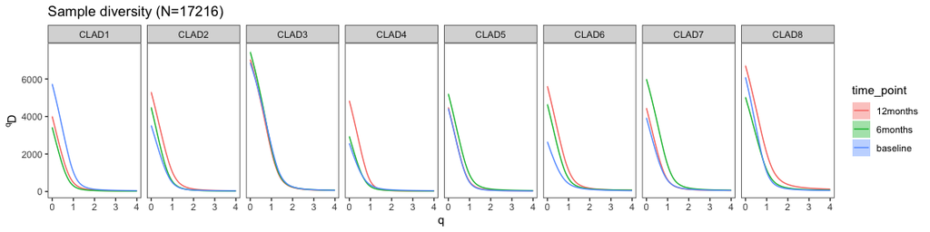

### Clonal diversity at specific q values

#### q=1

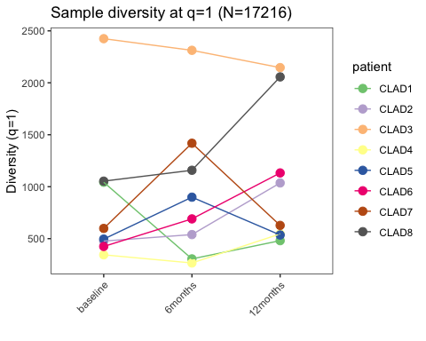

#### q=0

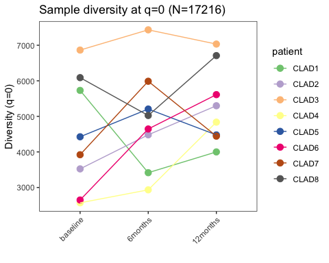

## Clonal diversity per cell population

[output not shown]

[figure not shown]

### Clonal diversity per population at specific q values

#### q=1

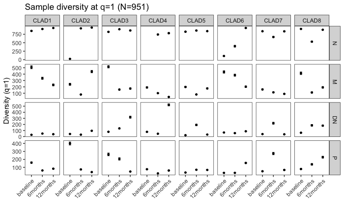

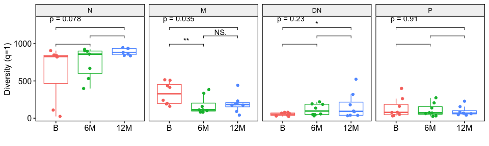

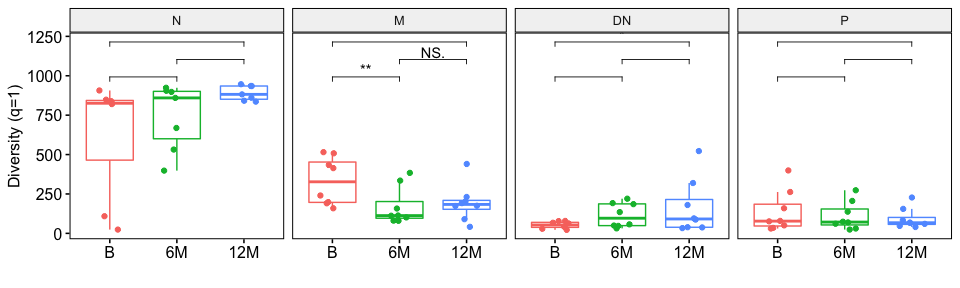

#### q=0

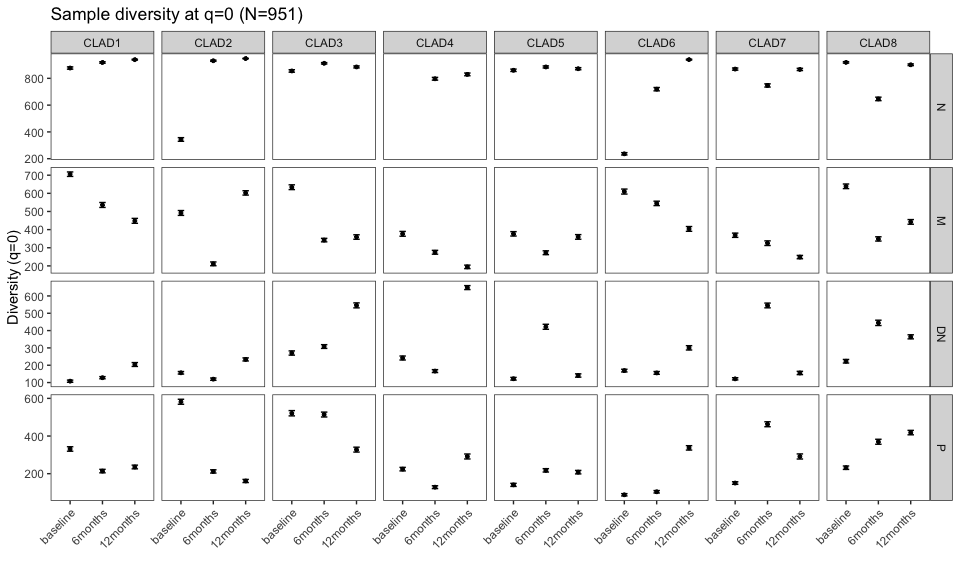

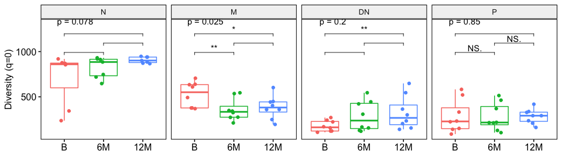

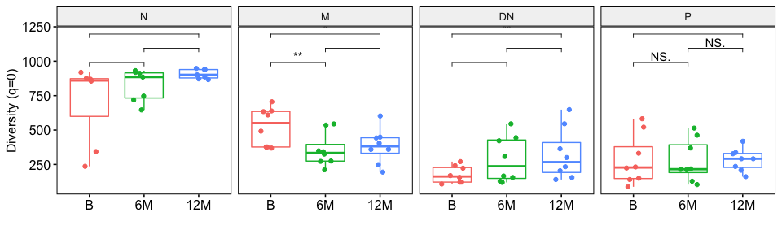

## Figure diversity and abundance metrics

[output not shown]

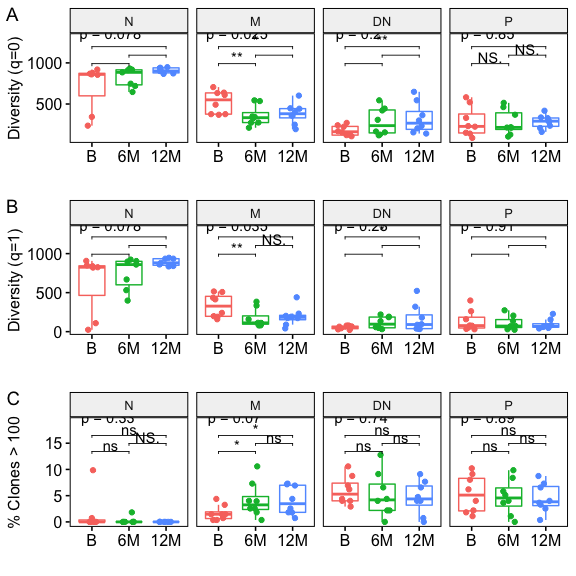

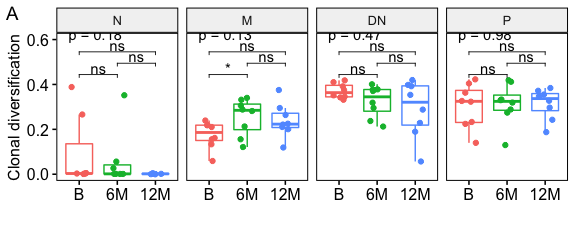

[output not shown]

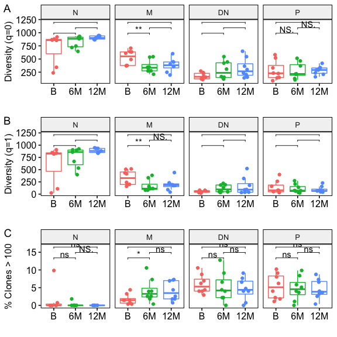

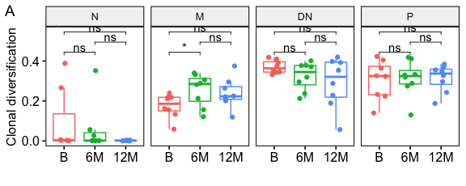

# V gene usage

## V gene usage

# Isotype usage

# Citations

If you use nf-core/bcellmagic for your analysis, please cite it using the following DOI: 10.5281/zenodo.3607408

Please also cite the `nf-core` publication (P. A. Ewels et al. 2020).

In addition, citations for the tools and data used in this pipeline are as follows:

- **pRESTO** (Vander Heiden et al. 2014)
- **SHazaM, Change-O** (Gupta et al. 2015)
- **Alakazam** (Stern et al. 2014)
- **TIgGER** (Gadala-Maria et al. 2015)
- **FastQC** (Andrews et al. 2010)
- **MultiQC** (P. Ewels et al. 2016)

Andrews, Simon et al. 2010. “FastQC: A Quality Control Tool for High Throughput Sequence Data.”

Ewels, Philip A., Alexander Peltzer, Sven Fillinger, Harshil Patel, Johannes Alneberg, Andreas Wilm, Maxime Ulysse Garcia, Paolo Di Tommaso, and Sven Nahnsen. 2020. “The Nf-Core Framework for Community-Curated Bioinformatics Pipelines.” *Nature Biotechnology* 38 (3): 276–78. https://doi.org/10.1038/s41587-020-0439-x.

Ewels, Philip, Måns Magnusson, Sverker Lundin, and Max Käller. 2016. “MultiQC: Summarize Analysis Results for Multiple Tools and Samples in a Single Report.” *Bioinformatics* 32 (19): 3047–48.

Gadala-Maria, Daniel, Gur Yaari, Mohamed Uduman, and Steven H. Kleinstein. 2015. “Automated Analysis of High-Throughput b-Cell Sequencing Data Reveals a High Frequency of Novel Immunoglobulin v Gene Segment Alleles.” *Proceedings of the National Academy of Sciences of the United States of America* 112 (8): E862–870. https://doi.org/10.1073/pnas.1417683112.

Gupta, Namita T., Jason A. Vander Heiden, Mohamed Uduman, Daniel Gadala-Maria, Gur Yaari, and Steven H. Kleinstein. 2015. “Change-o: A Toolkit for Analyzing Large-Scale b Cell Immunoglobulin Repertoire Sequencing Data.” *Bioinformatics* 31 (20): 3356–58. https://doi.org/10.1093/bioinformatics/btv359.

Stern, Joel N. H., Gur Yaari, Jason A. Vander Heiden, George Church, William F. Donahue, Rogier Q. Hintzen, Anita J. Huttner, et al. 2014. “B Cells Populating the Multiple Sclerosis Brain Mature in the Draining Cervical Lymph Nodes.” *Science Translational Medicine* 6 (248). https://doi.org/10.1126/scitranslmed.3008879.

Vander Heiden, Jason A., Gur Yaari, Mohamed Uduman, Joel N. H. Stern, Kevin C. O’Connor, David A. Hafler, Francois Vigneault, and Steven H. Kleinstein. 2014. “pRESTO: A Toolkit for Processing High-Throughput Sequencing Raw Reads of Lymphocyte Receptor Repertoires.” *Bioinformatics* 30 (13): 1930–32. https://doi.org/10.1093/bioinformatics/btu138.